# Eichhorn’s rule, the site index concept, and the development of yield levels

Carl Vigren

```r
library(forester)
library(tidyverse)
library(robustbase)
```

Sometimes called the ‘basic tenet’ of forestry, as we can read in Assmann (1970), Eichhorn’s rule (after Eichhorn (1904)) states that for silver fir :

“a given mean height of stand is matched by the same volume in all site classes”.

Given that: - There are only weak forestry operations - The volume corresponds to the volume, i.e. including dead and harvested volume.

You can find the tables used by Gehrhardt in the forester package.

```r
forester::Silver_fir_1921
```

```
#> # A tibble: 60 x 5
#>    Site_class   Age `Stem number` `Mean height m` `Total stem wood m3`
#>         <dbl> <dbl>         <dbl>           <dbl>                <dbl>
#>  1          1    10            NA             2.4                   12
#>  2          1    20            NA             6.5                   81
#>  3          1    30          2880            11.3                  220
#>  4          1    40          1820            16.1                  403
#>  5          1    50          1255            20.5                  605
#>  6          1    60           905            24.3                  806
#>  7          1    70           705            27.4                  991
#>  8          1    80           575            30                   1153
#>  9          1    90           490            32                   1288
#> 10          1   100           430            33.6                 1399
#> # … with 50 more rows
```

While the different site classes clearly achieve a mean height at different time scales:

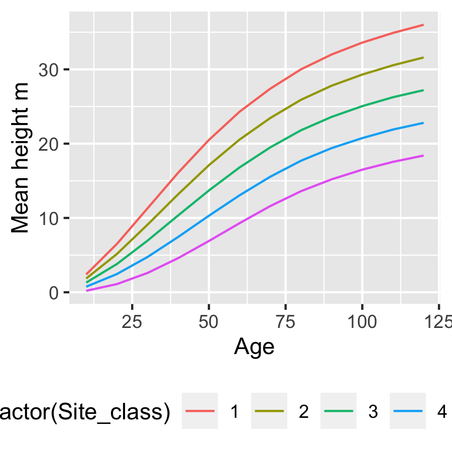

```r
Silver_fir_1921 %>% ggplot(aes(x=`Age`,y=`Mean height m`,color=factor(Site_class)))+geom_line()+theme(legend.position = "bottom")
```

There is no difference in the relation of the mean height and total yield (m3) between the site classes:

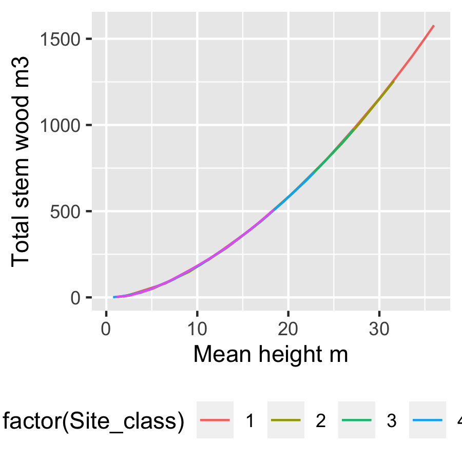

```r
Silver_fir_1921 %>% ggplot(aes(x=`Mean height m`,y=`Total stem wood m3`,color=factor(Site_class)))+geom_line()+theme(legend.position = "bottom")
```

We can test this by following a methodology suggested by Greg Johnson of the Weyerhauser Company at the Western Mensurationists meeting July 3, 2003.

By using `tidyr::nest`, we can fit functions to every set at the same time. First we create a copy of the data, in which we remove the Site classes, and then append it to the original data. We then nest the data by site class and give it a new name.

```r
alldata <- Silver_fir_1921 %>% mutate(Site_class="All")
sitedata <- rbind(Silver_fir_1921, alldata)

#We need to remove any NA's in Siteclass, volume or height.
sitedata <- sitedata %>% filter(!is.na(Site_class), !is.na(`Total stem wood m3`), !is.na(`Mean height m`)) %>% rename(Volume=`Total stem wood m3`, height=`Mean height m`)
sitedata <- sitedata %>% group_by(Site_class) %>% nest()
sitedata
```

```
#> # A tibble: 6 x 2
#> # Groups:   Site_class [6]
#>   Site_class           data
#>   <chr>      <list<df[,4]>>
#> 1 1                [12 × 4]
#> 2 2                [12 × 4]
#> 3 3                [12 × 4]
#> 4 4                [12 × 4]
#> 5 5                [11 × 4]
#> 6 All              [59 × 4]
```

```r
modfit <- function(df){
  nls(Volume ~ a * (height^b), data=df, start=c(a=1,b=1))
}
```

```r
sitedata_model <- sitedata %>%
  mutate(Model= purrr::map(.x=data, .f= modfit)) %>%
  # extract formula from each model, convert to one-sided form, &
  # replace coefficients with fitted values, & store in dataframe
  # as character string
  rowwise() %>%
  mutate(func = formula(Model) %>%
           as.character() %>%
           magrittr::extract(3) %>%
           gsub("height", ".x", ., fixed = T) %>%
           gsub("a", Model$m$getPars()[1], .) %>%
           gsub("b", Model$m$getPars()[2], .) %>%
           paste("~", ., collapse = "")) %>%
  ungroup()

print(sitedata_model)
```

```
#> # A tibble: 6 x 4
#>   Site_class           data Model  func
#>   <chr>      <list<df[,4]>> <list> <chr>
#> 1 1                [12 × 4] <nls>  ~ 3.52483398975447 * (.x^1.70294862755727)
#> 2 2                [12 × 4] <nls>  ~ 3.59566327041449 * (.x^1.69571498179408)
#> 3 3                [12 × 4] <nls>  ~ 3.62022829589491 * (.x^1.69411599734418)
#> 4 4                [12 × 4] <nls>  ~ 3.59857030691653 * (.x^1.69678911995089)
#> 5 5                [11 × 4] <nls>  ~ 3.4647917895332 * (.x^1.71367303586932)
#> 6 All              [59 × 4] <nls>  ~ 3.59769910772925 * (.x^1.6965523624939)
```

Let’s plot the different models.

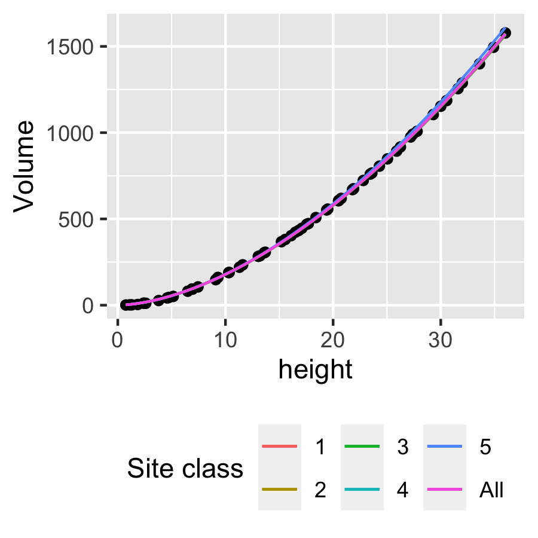

```r
ggplot(sitedata_model$data[[6]])+
  theme(legend.position = "bottom")+
  geom_point(aes(x=height,y=Volume)) + #All the data
    # add formula in each row as a separate geom_function layer
  lapply(seq(1, nrow(sitedata_model)),
         function(i) geom_function(fun = rlang::as_function(formula(sitedata_model$func[i])),
                                   aes(colour = sitedata_model$Site_class[i]))) +

  # change legend name (can also change palette / labels / etc.)
  scale_colour_discrete(name = "Site class")
```

The different models look almost indistinguishable, although the regression fit to Site Class V seems to be slightly different.

We’ll use an ANOVA to illustrate to what degree.

```r
anova(sitedata_model$Model[[1]],sitedata_model$Model[[2]],sitedata_model$Model[[3]],sitedata_model$Model[[4]],sitedata_model$Model[[5]],sitedata_model$Model[[6]])
```

```
#> Analysis of Variance Table
#>
#> Model 1: Volume ~ a * (height^b)
#> Model 2: Volume ~ a * (height^b)
#> Model 3: Volume ~ a * (height^b)
#> Model 4: Volume ~ a * (height^b)
#> Model 5: Volume ~ a * (height^b)
#> Model 6: Volume ~ a * (height^b)
#>   Res.Df Res.Sum Sq  Df  Sum Sq F value Pr(>F)
#> 1     10      60.14
#> 2     10     148.83   0    0.00
#> 3     10     100.22   0    0.00
#> 4     10      90.36   0    0.00
#> 5      9     100.15   1   -9.79 -0.8796 1.0000
#> 6     57     741.38 -48 -641.23  1.2005 0.4106
```